# Risk Factor Analysis

## Outcome Variable

**Outcome Variable:** sstunted

## Predictor Variables

**Intervention Variable:** mwtkg

**Adjustment Set:**

unadjusted

## Stratifying Variables

The analysis was stratified on these variable(s):

- agecat
- studyid

The following strata were considered:

- agecat: 12 months, studyid: ki0047075b-MAL-ED
- agecat: 12 months, studyid: ki1017093-NIH-Birth
- agecat: 12 months, studyid: ki1017093b-PROVIDE
- agecat: 12 months, studyid: ki1017093c-NIH-Crypto
- agecat: 12 months, studyid: ki1066203-TanzaniaChild2
- agecat: 12 months, studyid: ki1126311-ZVITAMBO
- agecat: 12 months, studyid: ki1148112-LCNI-5
- agecat: 18 months, studyid: ki0047075b-MAL-ED
- agecat: 18 months, studyid: ki1017093-NIH-Birth
- agecat: 18 months, studyid: ki1017093b-PROVIDE
- agecat: 18 months, studyid: ki1017093c-NIH-Crypto
- agecat: 18 months, studyid: ki1066203-TanzaniaChild2
- agecat: 18 months, studyid: ki1126311-ZVITAMBO
- agecat: 18 months, studyid: ki1148112-LCNI-5
- agecat: 24 months, studyid: ki0047075b-MAL-ED
- agecat: 24 months, studyid: ki1017093-NIH-Birth
- agecat: 24 months, studyid: ki1017093b-PROVIDE
- agecat: 24 months, studyid: ki1017093c-NIH-Crypto
- agecat: 24 months, studyid: ki1066203-TanzaniaChild2
- agecat: 24 months, studyid: ki1126311-ZVITAMBO
- agecat: 24 months, studyid: ki1148112-LCNI-5
- agecat: 3 months, studyid: ki0047075b-MAL-ED
- agecat: 3 months, studyid: ki1017093-NIH-Birth
- agecat: 3 months, studyid: ki1017093b-PROVIDE
- agecat: 3 months, studyid: ki1017093c-NIH-Crypto
- agecat: 3 months, studyid: ki1066203-TanzaniaChild2
- agecat: 3 months, studyid: ki1126311-ZVITAMBO
- agecat: 6 months, studyid: ki0047075b-MAL-ED
- agecat: 6 months, studyid: ki1017093-NIH-Birth
- agecat: 6 months, studyid: ki1017093b-PROVIDE
- agecat: 6 months, studyid: ki1017093c-NIH-Crypto
- agecat: 6 months, studyid: ki1066203-TanzaniaChild2
- agecat: 6 months, studyid: ki1126311-ZVITAMBO
- agecat: 6 months, studyid: ki1148112-LCNI-5
- agecat: 9 months, studyid: ki0047075b-MAL-ED
- agecat: 9 months, studyid: ki1017093-NIH-Birth
- agecat: 9 months, studyid: ki1017093b-PROVIDE
- agecat: 9 months, studyid: ki1017093c-NIH-Crypto
- agecat: 9 months, studyid: ki1066203-TanzaniaChild2
- agecat: 9 months, studyid: ki1126311-ZVITAMBO
- agecat: 9 months, studyid: ki1148112-LCNI-5
- agecat: Birth, studyid: ki0047075b-MAL-ED
- agecat: Birth, studyid: ki1017093-NIH-Birth
- agecat: Birth, studyid: ki1017093c-NIH-Crypto
- agecat: Birth, studyid: ki1126311-ZVITAMBO

### Dropped Strata

Some strata were dropped due to rare outcomes:

- agecat: Birth, studyid: ki1017093-NIH-Birth
- agecat: Birth, studyid: ki1017093c-NIH-Crypto
- agecat: Birth, studyid: ki1126311-ZVITAMBO
- agecat: 3 months, studyid: ki1017093-NIH-Birth
- agecat: 3 months, studyid: ki1017093b-PROVIDE
- agecat: 3 months, studyid: ki1017093c-NIH-Crypto
- agecat: 3 months, studyid: ki1066203-TanzaniaChild2
- agecat: 6 months, studyid: ki1017093-NIH-Birth
- agecat: 6 months, studyid: ki1017093b-PROVIDE
- agecat: 6 months, studyid: ki1017093c-NIH-Crypto
- agecat: 6 months, studyid: ki1066203-TanzaniaChild2
- agecat: 6 months, studyid: ki1126311-ZVITAMBO
- agecat: 6 months, studyid: ki1148112-LCNI-5
- agecat: 9 months, studyid: ki1017093-NIH-Birth
- agecat: 9 months, studyid: ki1017093b-PROVIDE
- agecat: 9 months, studyid: ki1017093c-NIH-Crypto
- agecat: 9 months, studyid: ki1066203-TanzaniaChild2
- agecat: 9 months, studyid: ki1126311-ZVITAMBO
- agecat: 9 months, studyid: ki1148112-LCNI-5
- agecat: 12 months, studyid: ki1017093b-PROVIDE
- agecat: 12 months, studyid: ki1017093c-NIH-Crypto
- agecat: 12 months, studyid: ki1066203-TanzaniaChild2
- agecat: 12 months, studyid: ki1148112-LCNI-5
- agecat: 18 months, studyid: ki1017093b-PROVIDE
- agecat: 18 months, studyid: ki1017093c-NIH-Crypto
- agecat: 18 months, studyid: ki1066203-TanzaniaChild2
- agecat: 18 months, studyid: ki1126311-ZVITAMBO
- agecat: 18 months, studyid: ki1148112-LCNI-5
- agecat: 24 months, studyid: ki1017093b-PROVIDE
- agecat: 24 months, studyid: ki1017093c-NIH-Crypto
- agecat: 24 months, studyid: ki1066203-TanzaniaChild2
- agecat: 24 months, studyid: ki1126311-ZVITAMBO
- agecat: 24 months, studyid: ki1148112-LCNI-5

## Methods Detail

We’re interested in the causal parameters $E[Y_a]$ for all values of $a \in \mathcal{A}$. These parameters represent the mean outcome if, possibly contrary to fact, we intervened to set all units to have $A=a$. Under the randomization and positivity assumptions, these are identified by the statistical parameters $\psi_a=E_W[E_{Y|A,W}(Y|A=a,W)]$. In addition, we’re interested in the mean of $Y$, $E[Y]$ under no intervention (the observed mean). We will estimate these parameters by using SuperLearner to fit the relevant likelihood factors – $E_{Y|A,W}(Y|A=a,W)$ and $p(A=a|W)$, and then updating our likelihood fit using a joint TMLE.

For unadjusted analyses ($W=\{\}$), initial likelihoods were estimated using Lrnr_glm to estimate the simple $E(Y|A)$ and Lrnr_mean to estimate $p(A)$. For adjusted analyses, a small library containing Lrnr_glmnet, Lrnr_xgboost, and Lrnr_mean was used.

Having estimated these parameters, we will then use the delta method to estimate relative risks and attributable risks relative to a prespecified baseline level of $A$.

# Results Detail

## Results Plots

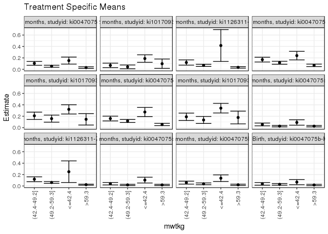

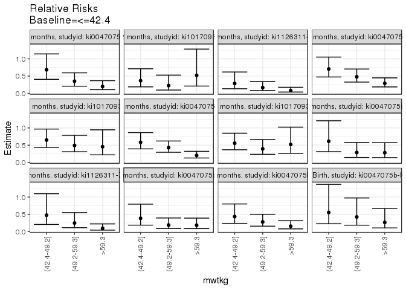

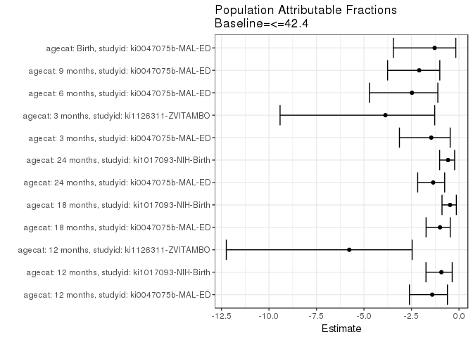

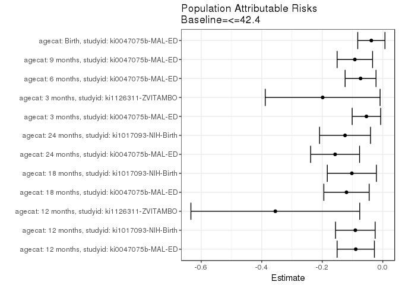

## Data Summary

| agecat | studyid | A | n | nA | nAY0 | nAY1 |
| --- | --- | --- | --- | --- | --- | --- |
| Birth | ki0047075b-MAL-ED | <=42.4 | 1425 | 119 | 111 | 8 |
| Birth | ki0047075b-MAL-ED | (42.4-49.2] | 1425 | 269 | 259 | 10 |
| Birth | ki0047075b-MAL-ED | (49.2-59.3] | 1425 | 529 | 514 | 15 |
| Birth | ki0047075b-MAL-ED | >59.3 | 1425 | 508 | 499 | 9 |
| Birth | ki1017093-NIH-Birth | <=42.4 | 28 | 12 | 12 | 0 |
| Birth | ki1017093-NIH-Birth | (42.4-49.2] | 28 | 9 | 9 | 0 |
| Birth | ki1017093-NIH-Birth | (49.2-59.3] | 28 | 7 | 7 | 0 |
| Birth | ki1017093-NIH-Birth | >59.3 | 28 | 0 | 0 | 0 |
| Birth | ki1017093b-PROVIDE | <=42.4 | 0 | 0 | 0 | 0 |
| Birth | ki1017093b-PROVIDE | (42.4-49.2] | 0 | 0 | 0 | 0 |
| Birth | ki1017093b-PROVIDE | (49.2-59.3] | 0 | 0 | 0 | 0 |
| Birth | ki1017093b-PROVIDE | >59.3 | 0 | 0 | 0 | 0 |
| Birth | ki1017093c-NIH-Crypto | <=42.4 | 27 | 8 | 8 | 0 |
| Birth | ki1017093c-NIH-Crypto | (42.4-49.2] | 27 | 9 | 9 | 0 |
| Birth | ki1017093c-NIH-Crypto | (49.2-59.3] | 27 | 7 | 6 | 1 |
| Birth | ki1017093c-NIH-Crypto | >59.3 | 27 | 3 | 3 | 0 |
| Birth | ki1066203-TanzaniaChild2 | <=42.4 | 0 | 0 | 0 | 0 |
| Birth | ki1066203-TanzaniaChild2 | (42.4-49.2] | 0 | 0 | 0 | 0 |
| Birth | ki1066203-TanzaniaChild2 | (49.2-59.3] | 0 | 0 | 0 | 0 |
| Birth | ki1066203-TanzaniaChild2 | >59.3 | 0 | 0 | 0 | 0 |
| Birth | ki1126311-ZVITAMBO | <=42.4 | 2710 | 28 | 27 | 1 |
| Birth | ki1126311-ZVITAMBO | (42.4-49.2] | 2710 | 300 | 284 | 16 |
| Birth | ki1126311-ZVITAMBO | (49.2-59.3] | 2710 | 1138 | 1091 | 47 |
| Birth | ki1126311-ZVITAMBO | >59.3 | 2710 | 1244 | 1229 | 15 |
| Birth | ki1148112-LCNI-5 | <=42.4 | 0 | 0 | 0 | 0 |
| Birth | ki1148112-LCNI-5 | (42.4-49.2] | 0 | 0 | 0 | 0 |
| Birth | ki1148112-LCNI-5 | (49.2-59.3] | 0 | 0 | 0 | 0 |
| Birth | ki1148112-LCNI-5 | >59.3 | 0 | 0 | 0 | 0 |
| 3 months | ki0047075b-MAL-ED | <=42.4 | 1759 | 143 | 130 | 13 |
| 3 months | ki0047075b-MAL-ED | (42.4-49.2] | 1759 | 341 | 322 | 19 |

[output cut: 166 more lines]

## Results Table

### Parameter: TSM

| agecat | studyid | intervention_level | baseline_level | estimate | ci_lower | ci_upper |
| --- | --- | --- | --- | --- | --- | --- |
| Birth | ki0047075b-MAL-ED | <=42.4 | NA | 0.0672269 | 0.0222192 | 0.1122346 |
| Birth | ki0047075b-MAL-ED | (42.4-49.2] | NA | 0.0371747 | 0.0145584 | 0.0597910 |
| Birth | ki0047075b-MAL-ED | (49.2-59.3] | NA | 0.0283554 | 0.0142058 | 0.0425050 |
| Birth | ki0047075b-MAL-ED | >59.3 | NA | 0.0177165 | 0.0062409 | 0.0291922 |
| 3 months | ki0047075b-MAL-ED | <=42.4 | NA | 0.0909091 | 0.0437776 | 0.1380405 |
| 3 months | ki0047075b-MAL-ED | (42.4-49.2] | NA | 0.0557185 | 0.0313659 | 0.0800710 |
| 3 months | ki0047075b-MAL-ED | (49.2-59.3] | NA | 0.0261137 | 0.0138599 | 0.0383674 |
| 3 months | ki0047075b-MAL-ED | >59.3 | NA | 0.0256410 | 0.0132357 | 0.0380463 |
| 3 months | ki1126311-ZVITAMBO | <=42.4 | NA | 0.2500000 | 0.0601826 | 0.4398174 |
| 3 months | ki1126311-ZVITAMBO | (42.4-49.2] | NA | 0.1181818 | 0.0755137 | 0.1608500 |
| 3 months | ki1126311-ZVITAMBO | (49.2-59.3] | NA | 0.0613839 | 0.0456634 | 0.0771045 |
| 3 months | ki1126311-ZVITAMBO | >59.3 | NA | 0.0232794 | 0.0138747 | 0.0326840 |
| 6 months | ki0047075b-MAL-ED | <=42.4 | NA | 0.1029412 | 0.0518539 | 0.1540284 |
| 6 months | ki0047075b-MAL-ED | (42.4-49.2] | NA | 0.0393939 | 0.0183994 | 0.0603885 |
| 6 months | ki0047075b-MAL-ED | (49.2-59.3] | NA | 0.0190779 | 0.0083841 | 0.0297717 |
| 6 months | ki0047075b-MAL-ED | >59.3 | NA | 0.0185497 | 0.0076867 | 0.0294128 |
| 9 months | ki0047075b-MAL-ED | <=42.4 | NA | 0.1363636 | 0.0778026 | 0.1949247 |
| 9 months | ki0047075b-MAL-ED | (42.4-49.2] | NA | 0.0590062 | 0.0332611 | 0.0847514 |
| 9 months | ki0047075b-MAL-ED | (49.2-59.3] | NA | 0.0378913 | 0.0226974 | 0.0530851 |
| 9 months | ki0047075b-MAL-ED | >59.3 | NA | 0.0209790 | 0.0092308 | 0.0327272 |
| 12 months | ki0047075b-MAL-ED | <=42.4 | NA | 0.1526718 | 0.0910616 | 0.2142820 |
| 12 months | ki0047075b-MAL-ED | (42.4-49.2] | NA | 0.1041009 | 0.0704722 | 0.1377297 |
| 12 months | ki0047075b-MAL-ED | (49.2-59.3] | NA | 0.0536013 | 0.0355287 | 0.0716739 |
| 12 months | ki0047075b-MAL-ED | >59.3 | NA | 0.0301418 | 0.0160268 | 0.0442569 |
| 12 months | ki1017093-NIH-Birth | <=42.4 | NA | 0.1884058 | 0.1230976 | 0.2537140 |
| 12 months | ki1017093-NIH-Birth | (42.4-49.2] | NA | 0.0687500 | 0.0295036 | 0.1079964 |
| 12 months | ki1017093-NIH-Birth | (49.2-59.3] | NA | 0.0422535 | 0.0091325 | 0.0753745 |
| 12 months | ki1017093-NIH-Birth | >59.3 | NA | 0.0980392 | 0.0163435 | 0.1797350 |
| 12 months | ki1126311-ZVITAMBO | <=42.4 | NA | 0.4166667 | 0.1376420 | 0.6956913 |
| 12 months | ki1126311-ZVITAMBO | (42.4-49.2] | NA | 0.1191710 | 0.0734482 | 0.1648938 |
| 12 months | ki1126311-ZVITAMBO | (49.2-59.3] | NA | 0.0689655 | 0.0501345 | 0.0877966 |
| 12 months | ki1126311-ZVITAMBO | >59.3 | NA | 0.0337382 | 0.0207341 | 0.0467423 |
| 18 months | ki0047075b-MAL-ED | <=42.4 | NA | 0.2400000 | 0.1651061 | 0.3148939 |
| 18 months | ki0047075b-MAL-ED | (42.4-49.2] | NA | 0.1693811 | 0.1274097 | 0.2113525 |
| 18 months | ki0047075b-MAL-ED | (49.2-59.3] | NA | 0.1149826 | 0.0888775 | 0.1410877 |
| 18 months | ki0047075b-MAL-ED | >59.3 | NA | 0.0692884 | 0.0477429 | 0.0908339 |
| 18 months | ki1017093-NIH-Birth | <=42.4 | NA | 0.3203125 | 0.2393928 | 0.4012322 |
| 18 months | ki1017093-NIH-Birth | (42.4-49.2] | NA | 0.2077922 | 0.1436430 | 0.2719414 |
| 18 months | ki1017093-NIH-Birth | (49.2-59.3] | NA | 0.1578947 | 0.0958566 | 0.2199329 |
| 18 months | ki1017093-NIH-Birth | >59.3 | NA | 0.1458333 | 0.0458801 | 0.2457865 |
| 24 months | ki0047075b-MAL-ED | <=42.4 | NA | 0.2735043 | 0.1927063 | 0.3543022 |
| 24 months | ki0047075b-MAL-ED | (42.4-49.2] | NA | 0.1593220 | 0.1175451 | 0.2010989 |
| 24 months | ki0047075b-MAL-ED | (49.2-59.3] | NA | 0.1167883 | 0.0898893 | 0.1436873 |
| 24 months | ki0047075b-MAL-ED | >59.3 | NA | 0.0554493 | 0.0358291 | 0.0750696 |
| 24 months | ki1017093-NIH-Birth | <=42.4 | NA | 0.3414634 | 0.2575630 | 0.4253639 |
| 24 months | ki1017093-NIH-Birth | (42.4-49.2] | NA | 0.1901408 | 0.1255229 | 0.2547588 |
| 24 months | ki1017093-NIH-Birth | (49.2-59.3] | NA | 0.1344538 | 0.0730899 | 0.1958177 |
| 24 months | ki1017093-NIH-Birth | >59.3 | NA | 0.1777778 | 0.0659417 | 0.2896139 |

### Parameter: E(Y)

| agecat | studyid | intervention_level | baseline_level | estimate | ci_lower | ci_upper |
| --- | --- | --- | --- | --- | --- | --- |
| Birth | ki0047075b-MAL-ED | NA | NA | 0.0294737 | 0.0287769 | 0.0301704 |
| 3 months | ki0047075b-MAL-ED | NA | NA | 0.0369528 | 0.0360252 | 0.0378805 |
| 3 months | ki1126311-ZVITAMBO | NA | NA | 0.0513183 | 0.0498184 | 0.0528181 |
| 6 months | ki0047075b-MAL-ED | NA | NA | 0.0296209 | 0.0285158 | 0.0307259 |
| 9 months | ki0047075b-MAL-ED | NA | NA | 0.0440906 | 0.0426083 | 0.0455730 |
| 12 months | ki0047075b-MAL-ED | NA | NA | 0.0633934 | 0.0615655 | 0.0652213 |
| 12 months | ki1017093-NIH-Birth | NA | NA | 0.0977597 | 0.0925405 | 0.1029789 |
| 12 months | ki1126311-ZVITAMBO | NA | NA | 0.0615104 | 0.0595247 | 0.0634960 |
| 18 months | ki0047075b-MAL-ED | NA | NA | 0.1201299 | 0.1176040 | 0.1226558 |
| 18 months | ki1017093-NIH-Birth | NA | NA | 0.2181425 | 0.2120214 | 0.2242637 |
| 24 months | ki0047075b-MAL-ED | NA | NA | 0.1159811 | 0.1129163 | 0.1190459 |
| 24 months | ki1017093-NIH-Birth | NA | NA | 0.2167832 | 0.2090102 | 0.2245562 |

### Parameter: RR

| agecat | studyid | intervention_level | baseline_level | estimate | ci_lower | ci_upper |
| --- | --- | --- | --- | --- | --- | --- |
| Birth | ki0047075b-MAL-ED | (42.4-49.2] | <=42.4 | 0.5529740 | 0.2237857 | 1.3663973 |
| Birth | ki0047075b-MAL-ED | (49.2-59.3] | <=42.4 | 0.4217864 | 0.1830022 | 0.9721398 |
| Birth | ki0047075b-MAL-ED | >59.3 | <=42.4 | 0.2635335 | 0.1038175 | 0.6689611 |
| 3 months | ki0047075b-MAL-ED | (42.4-49.2] | <=42.4 | 0.6129032 | 0.3110995 | 1.2074925 |
| 3 months | ki0047075b-MAL-ED | (49.2-59.3] | <=42.4 | 0.2872504 | 0.1427485 | 0.5780292 |
| 3 months | ki0047075b-MAL-ED | >59.3 | <=42.4 | 0.2820513 | 0.1387906 | 0.5731865 |
| 3 months | ki1126311-ZVITAMBO | (42.4-49.2] | <=42.4 | 0.4727273 | 0.2039310 | 1.0958173 |
| 3 months | ki1126311-ZVITAMBO | (49.2-59.3] | <=42.4 | 0.2455357 | 0.1101832 | 0.5471595 |
| 3 months | ki1126311-ZVITAMBO | >59.3 | <=42.4 | 0.0931174 | 0.0394015 | 0.2200641 |
| 6 months | ki0047075b-MAL-ED | (42.4-49.2] | <=42.4 | 0.3826840 | 0.1847462 | 0.7926932 |
| 6 months | ki0047075b-MAL-ED | (49.2-59.3] | <=42.4 | 0.1853282 | 0.0876603 | 0.3918140 |
| 6 months | ki0047075b-MAL-ED | >59.3 | <=42.4 | 0.1801975 | 0.0836327 | 0.3882589 |
| 9 months | ki0047075b-MAL-ED | (42.4-49.2] | <=42.4 | 0.4327122 | 0.2345969 | 0.7981345 |
| 9 months | ki0047075b-MAL-ED | (49.2-59.3] | <=42.4 | 0.2778693 | 0.1544084 | 0.5000465 |
| 9 months | ki0047075b-MAL-ED | >59.3 | <=42.4 | 0.1538462 | 0.0759629 | 0.3115814 |
| 12 months | ki0047075b-MAL-ED | (42.4-49.2] | <=42.4 | 0.6818612 | 0.4066317 | 1.1433804 |
| 12 months | ki0047075b-MAL-ED | (49.2-59.3] | <=42.4 | 0.3510888 | 0.2075093 | 0.5940134 |
| 12 months | ki0047075b-MAL-ED | >59.3 | <=42.4 | 0.1974291 | 0.1063996 | 0.3663382 |
| 12 months | ki1017093-NIH-Birth | (42.4-49.2] | <=42.4 | 0.3649038 | 0.1871248 | 0.7115830 |
| 12 months | ki1017093-NIH-Birth | (49.2-59.3] | <=42.4 | 0.2242687 | 0.0951788 | 0.5284415 |
| 12 months | ki1017093-NIH-Birth | >59.3 | <=42.4 | 0.5203620 | 0.2110312 | 1.2831115 |
| 12 months | ki1126311-ZVITAMBO | (42.4-49.2] | <=42.4 | 0.2860104 | 0.1321906 | 0.6188179 |
| 12 months | ki1126311-ZVITAMBO | (49.2-59.3] | <=42.4 | 0.1655172 | 0.0803095 | 0.3411296 |
| 12 months | ki1126311-ZVITAMBO | >59.3 | <=42.4 | 0.0809717 | 0.0373912 | 0.1753462 |
| 18 months | ki0047075b-MAL-ED | (42.4-49.2] | <=42.4 | 0.7057546 | 0.4738040 | 1.0512565 |
| 18 months | ki0047075b-MAL-ED | (49.2-59.3] | <=42.4 | 0.4790941 | 0.3257039 | 0.7047233 |
| 18 months | ki0047075b-MAL-ED | >59.3 | <=42.4 | 0.2887016 | 0.1858346 | 0.4485097 |
| 18 months | ki1017093-NIH-Birth | (42.4-49.2] | <=42.4 | 0.6487171 | 0.4353233 | 0.9667159 |
| 18 months | ki1017093-NIH-Birth | (49.2-59.3] | <=42.4 | 0.4929397 | 0.3089782 | 0.7864293 |
| 18 months | ki1017093-NIH-Birth | >59.3 | <=42.4 | 0.4552846 | 0.2193029 | 0.9451951 |
| 24 months | ki0047075b-MAL-ED | (42.4-49.2] | <=42.4 | 0.5825212 | 0.3924309 | 0.8646897 |
| 24 months | ki0047075b-MAL-ED | (49.2-59.3] | <=42.4 | 0.4270073 | 0.2935970 | 0.6210393 |
| 24 months | ki0047075b-MAL-ED | >59.3 | <=42.4 | 0.2027366 | 0.1278628 | 0.3214550 |
| 24 months | ki1017093-NIH-Birth | (42.4-49.2] | <=42.4 | 0.5568410 | 0.3661037 | 0.8469513 |
| 24 months | ki1017093-NIH-Birth | (49.2-59.3] | <=42.4 | 0.3937575 | 0.2344877 | 0.6612073 |
| 24 months | ki1017093-NIH-Birth | >59.3 | <=42.4 | 0.5206349 | 0.2649891 | 1.0229128 |

### Parameter: PAR

| agecat | studyid | intervention_level | baseline_level | estimate | ci_lower | ci_upper |
| --- | --- | --- | --- | --- | --- | --- |
| Birth | ki0047075b-MAL-ED | <=42.4 | NA | -0.0377532 | -0.0827663 | 0.0072599 |
| 3 months | ki0047075b-MAL-ED | <=42.4 | NA | -0.0539563 | -0.1010969 | -0.0068157 |
| 3 months | ki1126311-ZVITAMBO | <=42.4 | NA | -0.1986817 | -0.3885050 | -0.0088584 |
| 6 months | ki0047075b-MAL-ED | <=42.4 | NA | -0.0733203 | -0.1244195 | -0.0222211 |
| 9 months | ki0047075b-MAL-ED | <=42.4 | NA | -0.0922730 | -0.1508528 | -0.0336932 |
| 12 months | ki0047075b-MAL-ED | <=42.4 | NA | -0.0892783 | -0.1509157 | -0.0276410 |
| 12 months | ki1017093-NIH-Birth | <=42.4 | NA | -0.0906461 | -0.1561626 | -0.0251297 |
| 12 months | ki1126311-ZVITAMBO | <=42.4 | NA | -0.3551563 | -0.6341880 | -0.0761246 |
| 18 months | ki0047075b-MAL-ED | <=42.4 | NA | -0.1198701 | -0.1948066 | -0.0449336 |
| 18 months | ki1017093-NIH-Birth | <=42.4 | NA | -0.1021700 | -0.1833208 | -0.0210191 |
| 24 months | ki0047075b-MAL-ED | <=42.4 | NA | -0.1575232 | -0.2383792 | -0.0766671 |
| 24 months | ki1017093-NIH-Birth | <=42.4 | NA | -0.1246802 | -0.2089400 | -0.0404204 |

### Parameter: PAF

| agecat | studyid | intervention_level | baseline_level | estimate | ci_lower | ci_upper |
| --- | --- | --- | --- | --- | --- | --- |
| Birth | ki0047075b-MAL-ED | <=42.4 | NA | -1.2809123 | -3.457027 | -0.1672717 |
| 3 months | ki0047075b-MAL-ED | <=42.4 | NA | -1.4601399 | -3.134108 | -0.4639888 |
| 3 months | ki1126311-ZVITAMBO | <=42.4 | NA | -3.8715596 | -9.414988 | -1.2786480 |
| 6 months | ki0047075b-MAL-ED | <=42.4 | NA | -2.4752941 | -4.716492 | -1.1127764 |
| 9 months | ki0047075b-MAL-ED | <=42.4 | NA | -2.0928030 | -3.758058 | -1.0103646 |
| 12 months | ki0047075b-MAL-ED | <=42.4 | NA | -1.4083221 | -2.609271 | -0.6069768 |
| 12 months | ki1017093-NIH-Birth | <=42.4 | NA | -0.9272343 | -1.736854 | -0.3571172 |
| 12 months | ki1126311-ZVITAMBO | <=42.4 | NA | -5.7739274 | -12.243644 | -2.4647634 |
| 18 months | ki0047075b-MAL-ED | <=42.4 | NA | -0.9978378 | -1.731446 | -0.4612613 |
| 18 months | ki1017093-NIH-Birth | <=42.4 | NA | -0.4683632 | -0.893315 | -0.1387913 |
| 24 months | ki0047075b-MAL-ED | <=42.4 | NA | -1.3581793 | -2.172395 | -0.7529374 |
| 24 months | ki1017093-NIH-Birth | <=42.4 | NA | -0.5751377 | -1.019104 | -0.2287922 |